# A/B Testing

Amber Chang

2019/8/3

## **資料輸入與前處理**

```r
library("tidyverse")
setwd('C:/Users/TzuTzu/Desktop/ri/abtesting') #設定工作目錄
test.table <- read_csv("test_table.csv")
user.table <- read_csv("user_table.csv")
#查看table資訊，只會顯示前6筆
#data交易日期, device設備, test有無測試(0為對照組，灰色按鈕, 1為測試組，綠色按鈕), purchase_amount購買金額
head(test.table)
```

```
## # A tibble: 6 x 5
##   user_id date     device       test purchase_amount
##     <dbl> <chr>    <chr>       <dbl>           <dbl>
## 1    1983 2017/1/1 pc_web          0            33.7
## 2    4704 2017/1/1 android_app     1            30.2
## 3   14995 2017/1/1 ios_app         0            37.2
## 4   15089 2017/1/1 pc_web          0            49.8
## 5   17522 2017/1/1 pc_web          0            19.7
## 6     186 2017/1/1 pc_web          1            33.6
```

```r
#gender性別, service會員階級
head(user.table)
```

```
## # A tibble: 6 x 5
##   user_id gender service   age country
##     <dbl> <chr>  <chr>   <dbl> <chr>
## 1       1 male   golden     20 US
## 2       2 male   premium    53 US
## 3       3 female premium    44 TW
## 4       4 male   golden     44 UK
## 5       5 male   normal     20 US
## 6       6 female golden     26 UK
```

## **資料驗證**

- 因為希望能合併使用者資料與實驗資料，但擔心測試的使用者其實沒有相關之使用者資料，故需先確認二個資料表的人數

由結果可知：

- user.table 中有20000個不重複使用者
- test.table 中有19871個不重複使用者
- 同時出現在二個表格中有19871個不重複使用者

→ 即每個測試使用者都有對應之相關資料。

```r
#計算uesr.table有多少個不重複使用者
#nrow計算row數, unique不重複
print(paste("user_table 中不重複使用者數量:",
            nrow(unique(select(user.table, user_id)))))
```

```
## [1] "user_table 中不重複使用者數量: 20000"
```

```r
print(paste("test_table 中不重複使用者數量:",
            nrow(unique(select(test.table, user_id)))))
```

```
## [1] "test_table 中不重複使用者數量: 19871"
```

```r
#以user_id將test.table和user.table取交集
print(paste("重複出現在user_table與test_table中不重複使用者數量:",
            nrow(unique(
              inner_join(select(test.table, user_id),
                         select(user.table, user_id),
                         by = "user_id")))))
```

```
## [1] "重複出現在user_table與test_table中不重複使用者數量: 19871"
```

- 接下來，驗證實驗組與對照組之數量有無平衡

由結果可知，實驗組與對照組之次數，遠超過使用者數量。

→ 故這次實驗，應是以「每次購物」作為一個Experiment Entitu(實驗個體)。

```r
print(paste("實驗組次數:",
            sum(
              unique(test.table)$test == 1)
            ))
```

```
## [1] "實驗組次數: 50012"
```

```r
print(paste("對照組次數:",
            sum(
              unique(test.table)$test == 0)
            ))
```

```
## [1] "對照組次數: 49986"
```

- 確定實驗個體後，即可合併實驗表格與使用者資料

→ 邏輯應為:test_table資料全都需要，user_table則不用全部需要，故採用`left_join`方式。

```r
#left_join保留所有左邊之值
test.data <- left_join(test.table,
                       user.table,
                       by = "user_id")

head(test.data)
```

```
## # A tibble: 6 x 9
##   user_id date   device   test purchase_amount gender service   age country
##     <dbl> <chr>  <chr>   <dbl>           <dbl> <chr>  <chr>   <dbl> <chr>
## 1    1983 2017/~ pc_web      0            33.7 male   golden     37 US
## 2    4704 2017/~ androi~     1            30.2 male   golden     33 UK
## 3   14995 2017/~ ios_app     0            37.2 male   golden     31 US
## 4   15089 2017/~ pc_web      0            49.8 male   golden     38 US
## 5   17522 2017/~ pc_web      0            19.7 male   normal     35 UK
## 6     186 2017/~ pc_web      1            33.6 female golden     50 BR
```

- 變數類別轉換

上列結果顯示，其中data類別應為data(日期)，device、test、gender、service、country應為factor(因子)，故需做類別轉換。

```r
test.data$date <- as.Date(test.data$date, format = "%Y/%m/%d")

#[[i]]將tibble資料抓出一個vector，需用二個[[]]，如果只用一個[]，抓出之資料仍為tibble
for(i in c(3,4,6,7,9)){
  test.data[, i] <- as.factor(test.data[[i]])
}

head(test.data)
```

```
## # A tibble: 6 x 9
##   user_id date       device test  purchase_amount gender service   age
##     <dbl> <date>     <fct>  <fct>           <dbl> <fct>  <fct>   <dbl>
## 1    1983 2017-01-01 pc_web 0                33.7 male   golden     37
## 2    4704 2017-01-01 andro~ 1                30.2 male   golden     33
## 3   14995 2017-01-01 ios_a~ 0                37.2 male   golden     31
## 4   15089 2017-01-01 pc_web 0                49.8 male   golden     38
## 5   17522 2017-01-01 pc_web 0                19.7 male   normal     35
## 6     186 2017-01-01 pc_web 1                33.6 female golden     50
## # ... with 1 more variable: country <fct>
```

- 檢視敘述統計

```r
summary(test.data)
```

```
##     user_id           date                    device      test
##  Min.   :    1   Min.   :2017-01-01   android_app:20213   0:49988
##  1st Qu.: 4980   1st Qu.:2017-01-08   ios_app    :39866   1:50012
##  Median : 9990   Median :2017-01-16   pc_web     :39921
##  Mean   : 9995   Mean   :2017-01-15
##  3rd Qu.:14990   3rd Qu.:2017-01-23
##  Max.   :20000   Max.   :2017-01-30
##  purchase_amount    gender         service           age        country
##  Min.   : 0.00   female:50148   golden :51989   Min.   :14.00   BR: 4954
##  1st Qu.:32.00   male  :49852   normal :28005   1st Qu.:23.00   JP: 9957
##  Median :40.60                  premium:20006   Median :33.00   TW: 5029
##  Mean   :39.76                                  Mean   :33.48   UK:19927
##  3rd Qu.:48.33                                  3rd Qu.:43.00   US:60133
##  Max.   :81.40                                  Max.   :53.00
```

- 比較每個維度差異

1.實驗與對照組之差異

由結果可知，改成綠色按鈕(test=1)是有好的結果。

```r
#使用`summarise`中的`mean`，計算平均購買金額
test.data %>%
  group_by(test) %>%
  summarise(mean_purchase_amount = mean(purchase_amount))
```

```
## # A tibble: 2 x 2
##   test  mean_purchase_amount
##   <fct>                <dbl>
## 1 0                     36.2
## 2 1                     43.4
```

2.設備間之差異

```r
test.data %>%
  group_by(device) %>%
  summarise(mean_purchase_amount = mean(purchase_amount))
```

```
## # A tibble: 3 x 2
##   device      mean_purchase_amount
##   <fct>                      <dbl>
## 1 android_app                 35.8
## 2 ios_app                     41.7
## 3 pc_web                      39.8
```

3.性別差異

```r
test.data %>%
  group_by(gender) %>%
  summarise(mean_purchase_amount = mean(purchase_amount))
```

```
## # A tibble: 2 x 2
##   gender mean_purchase_amount
##   <fct>                 <dbl>
## 1 female                 39.8
## 2 male                   39.7
```

4.服務類型差異

```r
test.data %>%
  group_by(service) %>%
  summarise(mean_purchase_amount = mean(purchase_amount))
```

```
## # A tibble: 3 x 2
##   service mean_purchase_amount
##   <fct>                  <dbl>
## 1 golden                  43.3
## 2 normal                  36.2
## 3 premium                 35.5
```

5.國家差異

```r
test.data %>%
  group_by(country) %>%
  summarise(mean_purchase_amount = mean(purchase_amount))
```

```
## # A tibble: 5 x 2
##   country mean_purchase_amount
##   <fct>                  <dbl>
## 1 BR                      19.1
## 2 JP                      39.0
## 3 TW                      30.0
## 4 UK                      29.8
## 5 US                      45.7
```

6.國家與實驗之交互影響

由結果可知，在每個國家中，test=1幾乎都比test=0有較高之平均購買金額，只有在日本反過來，為交互作用。

```r
#因為要計算二者間之影響，故`group_by`需加入二個變數
test.data %>%
  group_by(country, test) %>%
  summarise(mean_purchase_amount = mean(purchase_amount))
```

```
## # A tibble: 10 x 3
## # Groups:   country [5]
##    country test  mean_purchase_amount
##    <fct>   <fct>                <dbl>
##  1 BR      0                     14.6
##  2 BR      1                     23.4
##  3 JP      0                     43.6
##  4 JP      1                     34.5
##  5 TW      0                     25.3
##  6 TW      1                     34.8
##  7 UK      0                     25.3
##  8 UK      1                     34.3
##  9 US      0                     41.2
## 10 US      1                     50.3
```

## **資料分析**

### **獨立樣本T檢定**

**獨立樣本T檢定** - 用以檢視實驗組與對照組是否有不同結果。

```
假設x為購買金額，
測試組~常態分配, 對照組~常態分配
希望檢驗
虛無假設:測試組平均購買金額 - 對照組平均購買金額≦0 v.s 對立假設:測試組平均購買金額 - 對照組平均購買金額＞0
```

由結果可知，p-value非常小，即可拒絕虛無假設，表實驗組平均數>對照組平均數。

```r
#alternative = "greater", 對立假設>0
#alternative = "less", 對立假設<0
#alternative = "on-equal", 對立假設=0
t.test(test.data[test.data$test == 1, ]$purchase_amount, #測試組的購買金額
       test.data[test.data$test == 0, ]$purchase_amount,
       alternative = "greater")
```

```
##
##  Welch Two Sample t-test
##
## data:  test.data[test.data$test == 1, ]$purchase_amount and test.data[test.data$test == 0, ]$purchase_amount
## t = 100.88, df = 99961, p-value < 2.2e-16
## alternative hypothesis: true difference in means is greater than 0
## 95 percent confidence interval:
##  7.105031      Inf
## sample estimates:
## mean of x mean of y
##  43.37379  36.15099
```

### **變異數分析**

**變異數分析** - 瞭解因子是否會影響目標。

→ p-value<0.05或有***者，表有顯著差異

由結果可知，test.country.device.country會影響購買金額。

```r
#反映變數 ~ 解釋變數
#如果是單因子，~ 後填入一個變數即可
#test.data為資料來源
aov.model <- aov(
  purchase_amount ~ test + country + device + gender + service,
  test.data)
summary(aov.model)
```

```
##                Df  Sum Sq Mean Sq   F value Pr(>F)
## test            1 1304220 1304220 29002.182 <2e-16 ***
## country         4 6750567 1687642 37528.395 <2e-16 ***
## device          2  467118  233559  5193.694 <2e-16 ***
## gender          1      12      12     0.266  0.606
## service         2 1100841  550421 12239.802 <2e-16 ***
## Residuals   99989 4496478      45
## ---
## Signif. codes:  0 '***' 0.001 '**' 0.01 '*' 0.05 '.' 0.1 ' ' 1
```

### **交互作用**

**交互作用** - 瞭解某因子與其他因素是否會互相影響。

由結果可知，test與country有明顯交互作用。

```r
interaction.model <- aov(
  purchase_amount ~ test*country + test*device + test*service,
  test.data)
summary(interaction.model)
```

```
##                 Df  Sum Sq Mean Sq   F value Pr(>F)
## test             1 1304220 1304220 34766.465 <2e-16 ***
## country          4 6750567 1687642 44987.291 <2e-16 ***
## device           2  467118  233559  6225.958 <2e-16 ***
## service          2 1100830  550415 14672.356 <2e-16 ***
## test:country     4  745529  186382  4968.375 <2e-16 ***
## test:device      2      27      13     0.358 0.6994
## test:service     2     246     123     3.276 0.0378 *
## Residuals    99982 3750699      38
## ---
## Signif. codes:  0 '***' 0.001 '**' 0.01 '*' 0.05 '.' 0.1 ' ' 1
```

### **最終模型**

**最終模型** - 建立最能捕捉結果之交互模型。

```r
interaction.model <- aov(
  purchase_amount ~ test*country + device + service, #~ 後只留有顯著差異的
  test.data)
summary(interaction.model)
```

```
##                 Df  Sum Sq Mean Sq F value Pr(>F)
## test             1 1304220 1304220   34765 <2e-16 ***
## country          4 6750567 1687642   44986 <2e-16 ***
## device           2  467118  233559    6226 <2e-16 ***
## service          2 1100830  550415   14672 <2e-16 ***
## test:country     4  745529  186382    4968 <2e-16 ***
## Residuals    99986 3750972      38
## ---
## Signif. codes:  0 '***' 0.001 '**' 0.01 '*' 0.05 '.' 0.1 ' ' 1
```

### **事後檢定**

**Turkey事後檢定** - 瞭解每個因子的影響程度。

由結果可知，信賴區間非常窄，表示1與0差很多。

```r
#TukeyHSD(最終模型, 想要觀察之因子)
#diff為1-0之平均差異
#lwr, upr為95%信賴區間
TukeyHSD(interaction.model, "test")
```

```
##   Tukey multiple comparisons of means
##     95% family-wise confidence level
##
## Fit: aov(formula = purchase_amount ~ test * country + device + service, data = test.data)
##
## $test
##         diff      lwr      upr p adj
## 1-0 7.222798 7.146874 7.298722     0
```

```r
TukeyHSD(interaction.model, "country")
```

```
##   Tukey multiple comparisons of means
##     95% family-wise confidence level
##
## Fit: aov(formula = purchase_amount ~ test * country + device + service, data = test.data)
##
## $country
##             diff        lwr         upr     p adj
## JP-BR 19.9913255 19.7008418 20.28180930 0.0000000
## TW-BR 11.0518084 10.7173651 11.38625165 0.0000000
## UK-BR 10.7727908 10.5075467 11.03803485 0.0000000
## US-BR 26.7366260 26.4896678 26.98358416 0.0000000
## TW-JP -8.9395171 -9.2285509 -8.65048341 0.0000000
## UK-JP -9.2185348 -9.4235777 -9.01349179 0.0000000
## US-JP  6.7453004  6.5645339  6.92606700 0.0000000
## UK-TW -0.2790176 -0.5426729 -0.01536234 0.0318331
## US-TW 15.6848176 15.4395666 15.93006854 0.0000000
## US-UK 15.9638352 15.8272697 16.10040074 0.0000000
```

- 視覺化Tukey檢定

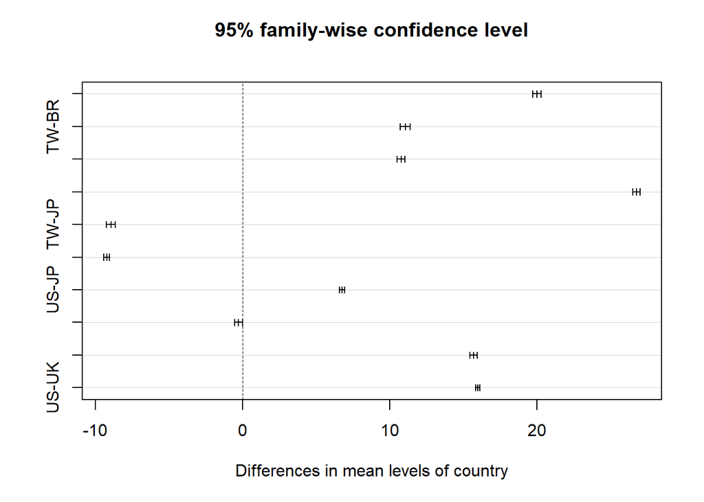

```r
plot(TukeyHSD(interaction.model, "country"))
```

## **視覺化結果呈現**

### **實驗組與對照組是否有顯著差異**

- 以**時間序列**，呈現每日差別

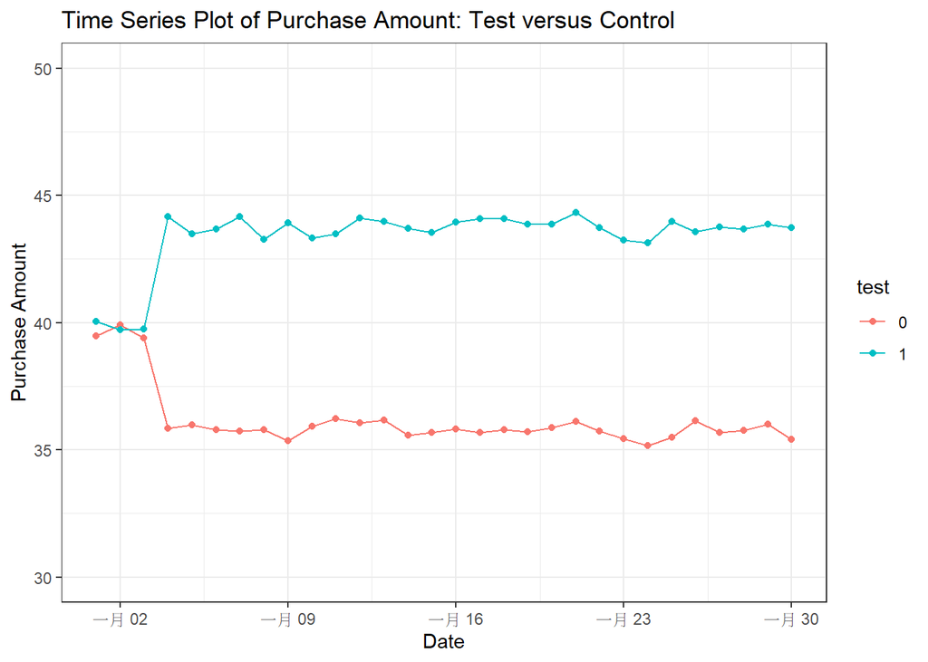

```r
#計算每個日期，實驗組與對照組之平均購買金額
daily.purchase <- test.data %>%
  group_by(date, test) %>%
  summarise(purchase_amount = mean(purchase_amount))

ggplot(daily.purchase, aes(x = date, y = purchase_amount, colour = test)) +
  geom_point() + geom_line() +
  xlab("Date") + ylab("Purchase Amount") + ylim(c(30, 50)) +
  ggtitle("Time Series Plot of Purchase Amount: Test versus Control") +
  theme_bw()
```

- 以**密度圖**，呈現一個月二族群之差別

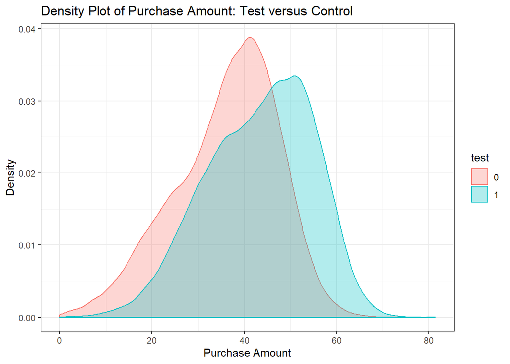

```r
#fill = test以test去填滿, colour = test以test去區分顏色
ggplot(test.data, aes(purchase_amount, fill = test, colour = test)) +
  geom_density(alpha = 0.3) +
  xlab("Purchase Amount") + ylab("Density") +
  ggtitle("Density Plot of Purchase Amount: Test versus Control") +
  theme_bw()
```

### **哪些因素會影響使用者之消費金額**

建議使用baxplot(盒狀圖)或density plot(機率密度圖)視覺化影響因素

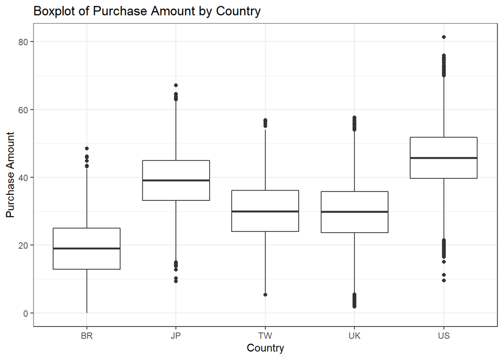

```r
ggplot(test.data, aes(x = country, y = purchase_amount)) + #x軸一定要是因子的變數
  geom_boxplot() +
  xlab("Country") + ylab("Purchase Amount") +
  ggtitle("Boxplot of Purchase Amount by Country") +
  theme_bw()
```

### **哪些因素存在交互作用**

由結果得知，日本實驗和對照組與他國相反。 → 如果要在日本有高購買金額，不要改掉原先之按鈕顏色。

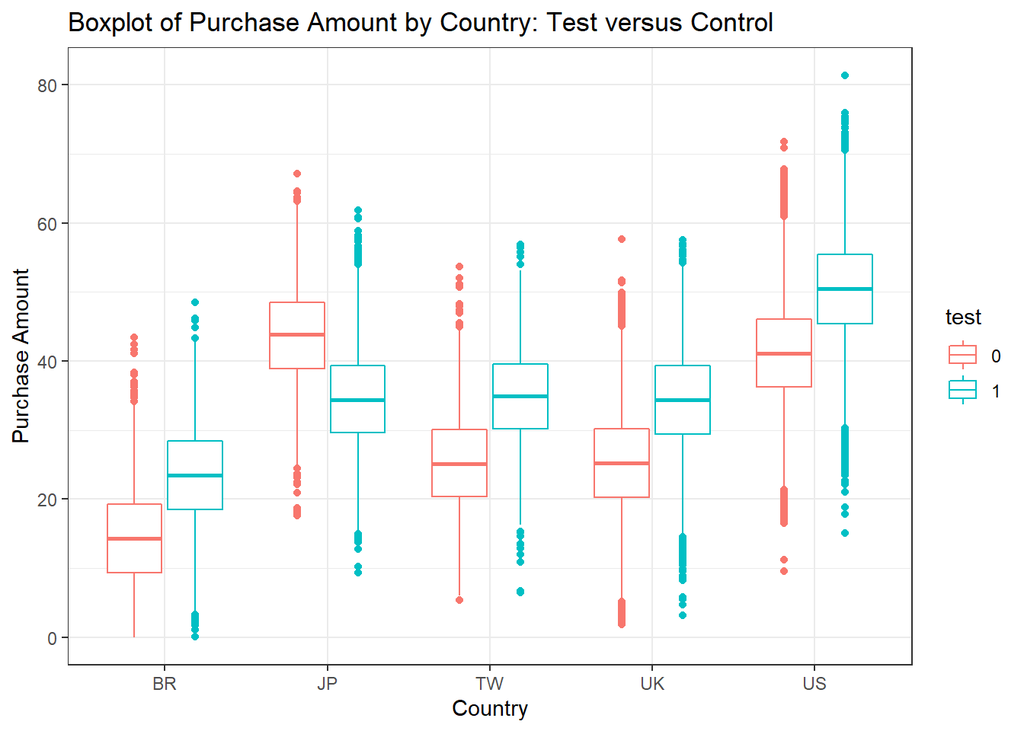

```r
ggplot(test.data, aes(x = country, y = purchase_amount, colour = test)) + #用顏色區分實驗與對照組
  geom_boxplot() +
  xlab("Country") + ylab("Purchase Amount") +
  ggtitle("Boxplot of Purchase Amount by Country: Test versus Control") +
  theme_bw()
```